© Guven

# Introduction to Generative Adversarial Networks

```
"What I cannot create, I do not understand", Richard Feynman
```

Generative Adversarial Networks (GANs) have brought popular innovative solutions to the machine learning (ML) community. These technical methods have changed the way researchers and engineers solve practical problems in several fields.

GANs have been applied to various domains such as computer vision, natural language processing, time series synthesis, semantic segmentation etc. GANs belong to the family of generative models. Comparing to other generative models e.g., variational autoencoders, GANs offer advantages such as an ability to handle sharp estimated density functions, efficiently generating desired samples, eliminating deterministic bias and good compatibility with the internal neural architecture. These properties have allowed GANs to enjoy success especially in the computer vision field e.g., plausible image generation, image to image translation, image super-resolution, and image completion.

## Introducing Adversarial Learning

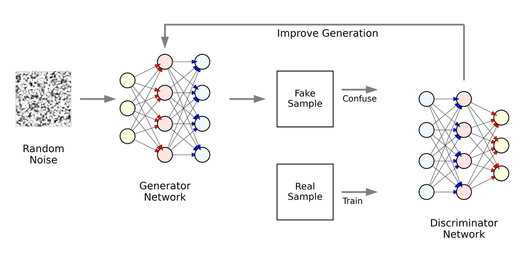

Traditionally, generative problems are solved by statistical methods such as Boltzmann machines, Markov chains, or variational encoders. As mathematically profound as they are, their generated samples are still far from perfect. A classification model maps high-dimensional data to low-dimensions, while a generative model often maps low dimensional data to high-dimensions.

A novel approach is combining two machines face to face, such as taking the output of a generative model as the input of the classification model. The performance of the generative model (the armor) with the classification model (the sword). At the same time, we can improve the classification model (the sword) by feeding generated samples (the armor) along with real samples, since we can agree that more data is often better for the training of ML models. The training process where the two models try to weaken each other and, as a result, improve each other is called adversarial learning. As demonstrated in the following diagram, the models, A and B, have totally opposite optimization goals of classification and generation. As a result, during each step of the training, the output of the model A improves the model B, and vice versa.

## Theory

Given $G$ and $D$ as the generator and discriminator networks, let $V$ represent the performance criterion of the system. The optimization objective is described as,

$\underset{G}{\min}\underset{D}{\max}V(D,G) = \mathbf{E}_x[\log D(x)] + \mathbf{E}_{x^*}[\log (1-D(x^*))]$

where $x$ is the real sample, $x^* = G(z)$ is the generated sample and $z$ is the random noise that $G$ uses to generate fake samples. $\mathbf{E}_x$ is the expectation over $x$. Maximize the prediction of real samples, thus train $D$ with gradient ascent, and the update rule of $D$ becomes,

$\theta_d \longleftarrow \theta_d + \frac{1}{m} \nabla_{\theta_d} \sum\limits_{i=1}^m \big( \log D(x_i)+\log (1-D(x_i^*)) \big)$

where $\theta_d$ are all the weights in the network $D$. $m$ is the batch size and $i$ is the index of the batch.

where $\theta_g$ are all the weights in the network $G$.

## Introduction to Deep Convolutional GANs

The majority of deep learning systems are artificial neural networks (ANNs, or just neural networks for short) with multiple stacked perceptrons and cascaded hidden layers. For this reason, deep learning has now almost become synonymous with deep neural networks. Note that any system that employs many layers to learn high level representations of the input data is also a form of deep learning (such as deep belief networks and deep Boltzmann machines).

One of the most common is the dense layer that connects all units in the layer directly to every unit in the previous layer. By stacking layers, the units in each subsequent layer can represent increasingly sophisticated aspects of the original input. Such as, learning the simplest Lego pieces at the first layer and then learning the linear combinations of Lego pieces to make up more complex pieces and then eventually learning the large complex structure that the data point(s) represent(s). Recall the error of each layer is minimized during training via the back propagation algorithm.

A Convolutional Neural network CNN is a multiple-layer neural network that consists of convolutional layers, pooling layers, and fully connected layers as hidden layers. In a convolution layer, a filter is slid across the data, and feature maps are extracted through element-wise multiplication. In general, a convolution layer has multiple filters, where one filter creates one feature map. The role of this layer is **feature extraction**.

The convolution is performed by multiplying the filter pixel-wise with the portion of the image, and summing the result. The output is more positive when the portion of the image closely matches the filter and more negative when the portion of the image is the inverse of the filter. If we move the filter across the entire image, from left to right and top to bottom, recording the convolutional output as we go, we obtain a new array that picks out a particular feature of the input, depending on the values in the filter.

This is exactly what a convolutional layer is designed to do, but with multiple filters rather than just one. For example, below shows two filters that highlight horizontal and vertical edges.

If we are working with color images, then each filter would have three channels rather than one (i.e. each having shape $3 \times 3 \times 3$) to match the three channels (red, green, blue) of the image.

The following example is a $3\times3$ portion of an image (left) convolved by two different filters.

$\scriptsize \begin{array}{|r|r|} \hline 0.6 & 0.2 & 0.6 \\ \hline 0.1 & -0.2 & -0.3 \\ \hline -0.5 & -0.1 & -0.3 \\ \hline \end{array} \quad {*} \quad \begin{array}{|r|r|} \hline 1 & 1 & 1 \\ \hline 0 & 0 & 0 \\ \hline -1 & -1 & -1 \\ \hline \end{array} \quad = \quad 2.3$

$\scriptsize \begin{array}{|r|r|} \hline 0.6 & 0.2 & 0.6 \\ \hline 0.1 & -0.2 & -0.3 \\ \hline -0.5 & -0.1 & -0.3 \\ \hline \end{array} \quad {*} \quad \begin{array}{|r|r|} \hline \,\; 1 & \,\; 0 & -1 \\ \hline 1 & 0 & -1 \\ \hline 1 & 0 & -1 \\ \hline \end{array} \quad = \quad 0.2$

The following example is a $4\times4$ portion of an image convolved by the previous filter with a stride of 1 and kernel size of 3 (basically the size of the filter, 3 by 3).

Note that in PyTorch `Conv2d` expects an order 4 Tensor which has the batch size and channel size as well. The following code demonstrates the convolution in PyTorch.

```python
%matplotlib inline
import matplotlib.pyplot as plt
import numpy as np

import torch
import torchvision

print(f'PyTorch version= {torch.__version__}')
print(f'torchvision version= {torchvision.__version__}')
print(f'CUDA available= {torch.cuda.is_available()}')
```

```
PyTorch version= 2.0.1
torchvision version= 0.15.2
CUDA available= True
```

```python
if torch.cuda.is_available():
    # CUDA Installation
    print('CUDA Version')
    !nvcc --version
    print()

    # CUDNN Installation
    print(f'CUDNN Version: {torch.backends.cudnn.version()}')
    print(f'Number of CUDA Devices: {torch.cuda.device_count()}')
    print(f'Active CUDA Device: {torch.cuda.current_device()}')
    print(f'Available devices: {torch.cuda.device_count()}, Name: {torch.cuda.get_device_name(0)}')
    print(f'Current CUDA device: {torch.cuda.current_device()}')
```

```
CUDA Version
nvcc: NVIDIA (R) Cuda compiler driver
Copyright (c) 2005-2022 NVIDIA Corporation
Built on Wed_Jun__8_16:59:34_Pacific_Daylight_Time_2022
Cuda compilation tools, release 11.7, V11.7.99
Build cuda_11.7.r11.7/compiler.31442593_0

CUDNN Version: 8500
Number of CUDA Devices: 1
Active CUDA Device: 0
Available devices: 1, Name: NVIDIA RTX 5000 Ada Generation
Current CUDA device: 0
```

```python
# Portion of the image
x = torch.FloatTensor([[0.6,0.2,0.6],[0.1,-0.2,-0.3],[-0.5,-0.1,-0.3]]).reshape(1,1,3,3)

# A filter
cnn_filter = torch.FloatTensor([[1,1,1],[0,0,0],[-1,-1,-1]]).reshape(1,1,3,3)

# 2D convolution operator
conv = torch.nn.Conv2d(1, 1, 3, bias=False)

# Set the filter weights as above
conv.weight.data = cnn_filter

# Filter
print(conv(x))

# Set the filter weights as above
conv.weight.data = torch.FloatTensor([[1,0,-1],[1,0,-1],[1,0,-1]]).reshape(1,1,3,3)

# Filter
print(conv(x))
```

```
tensor([[[[2.3000]]]], grad_fn=<ConvolutionBackward0>)
tensor([[[[0.2000]]]], grad_fn=<ConvolutionBackward0>)
```

```python
# A larger portion of the image
x = torch.FloatTensor([[0.1,0.6,0.2,0.6],[0.1,0.1,-0.2,-0.3],[0.1,-0.5,-0.1,-0.3],[0.1,0.1,-0.1,-0.1]]).reshape(1,1,4,4)

# Set the filter weights as above
conv.weight.data = cnn_filter

# Filter
print(conv(x))
```

```
tensor([[[[ 1.4000,  2.3000],
          [-0.1000, -0.3000]]]], grad_fn=<ConvolutionBackward0>)
```

## Batch Normalization

One common problem training a deep neural network is ensuring the weights of the network remain within a reasonable range of values. If they start to become too large, then the gradients will grow (explode) and as errors are propagated backward through the network, the calculation of the gradient in the earlier layers can grow exponentially large, causing wild fluctuations in the weight values. If the loss function starts to return NaN, chances are that weights have grown large enough to cause overflow. This may not happen immediately as the start of the training but sometimes the network and the loss function can suddenly start returning NaN.

One of the reasons for scaling input data into a neural network is to ensure a stable start to training over the first few iterations. Since the weights of the network are initially randomized, unscaled input could potentially create huge activation values that immediately lead to exploding gradients. For example, instead of passing pixel values from 0 to 255 into the input layer, we usually scale these values to between –1 and 1. Because the input is scaled, it's natural to expect the activations from all future layers to be relatively well scaled as well. Initially, this may be true, but as the network trains and the weights move further away from their random initial values, this assumption can start to break down. This phenomenon is known as covariate shift.

Batch normalization is a solution that drastically reduces this problem. The solution is surprisingly simple. A batch normalization layer calculates the mean and standard deviation of each of its input channels across the batch and normalizes by subtracting the mean and dividing by the standard deviation. There are then two learned parameters for each channel, the scale (gamma) and shift (beta). The output is simply the normalized input, scaled by gamma and shifted by beta.

**Input:** Batch $\text{B}=\{x_1, \dots, x_m\}$, learn parameters $\gamma$, $\beta$

**Output:** $y_i=\text{BN}_{\gamma,\beta}(x_i)$

Batch mean,  
$\mu_{B} \leftarrow \frac{1}{m}\sum\limits{i=1}{m}x_i$

Batch variance,  
$\sigma^2_{B} \leftarrow \frac{1}{m}\sum\limits{i=1}{m}(x_i - \mu_B)^2$

Normalize,  
$\hat{x}_i \leftarrow \frac{x_i - \mu_B}{\sqrt{\sigma^2_{B}+\epsilon}}$

Scale and shift,  
$y_i \leftarrow \gamma \hat{x}_i + \beta \equiv \text{BN}_{\gamma,\beta}(x_i)$

Place the batch normalization layers after dense or convolutional layers to normalize the output from those layers. In a way, those layers are connected by small sets of adjustable springs that ensure there aren't any overall huge shifts in their weights over time.

## A CNN Example on MNIST Dataset

The following example uses MNIST dataset and Fashion MNIST dataset.

Install torchvision for datasets and utility functions: `conda install -c pytorch torchvision`

```python
import sys

from sklearn.metrics import accuracy_score

import torch
import torch.nn as nn
import torch.optim as optim
import torch.utils.data
import torchvision.datasets as dset
import torchvision.transforms as vtransforms
import torchvision.utils as vutils

import torch.backends.cudnn as cudnn
cudnn.benchmark = True  # Might benefit if the nnet instance remains same

device = torch.device("cuda:0" if torch.cuda.is_available() else "cpu")

# Hide some PyTorch warnings (bugs)
import warnings
warnings.filterwarnings('ignore')
```

```python
# Get the training and testing datasets from a path with resize and normalization
def get_dataloader(_img_size, _bs, _ds, _path):
    train_ds = _ds(
        root=_path, download=False, train=True,
        transform=vtransforms.Compose([
            vtransforms.Resize(_img_size),
            vtransforms.ToTensor(),
            vtransforms.Normalize((0.5,), (0.5,))
        ]))

    # Use pin_memory=True to fix GPU memory
    train_dl = torch.utils.data.DataLoader(train_ds, batch_size=_bs, shuffle=True,
                                           #pin_memory=True,
                                           num_workers=4)

    test_ds = _ds(
        root=_path, download=False, train=False,
        transform=vtransforms.Compose([
            vtransforms.Resize(_img_size),
            vtransforms.ToTensor(),
            vtransforms.Normalize((0.5,), (0.5,))
        ]))

    test_dl = torch.utils.data.DataLoader(test_ds, batch_size=_bs, shuffle=True,
                                          #pin_memory=True,
                                          num_workers=4)

    return train_dl, test_dl

# Requires data files to be under MNIST/raw at the root location
# i.e. ../../../EP_datasets/mnist/MNIST/raw
def get_dl_mnist(_img_size, _bs):
    return get_dataloader(_img_size, _bs, dset.MNIST, '../../../EP_datasets/mnist')

# Requires data files to be under MNIST/raw at the root location
# i.e. ../../../EP_datasets/fashionmnist/FashionMNIST/raw
def get_dl_fashionmnist(_img_size, _bs):
    return get_dataloader(_img_size, _bs, dset.FashionMNIST, '../../../EP_datasets/fashion-mnist')
```

```python
# Initialize conv layers with N(0,0.02), batch norm layers N(1,0.02) and 0 bias
def init_weights(_m):
    if isinstance(_m, nn.Conv2d) or isinstance(_m, nn.ConvTranspose2d):
        torch.nn.init.normal_(_m.weight, mean=0.0, std=0.02)
    if isinstance(_m, nn.BatchNorm2d):
        torch.nn.init.normal_(_m.weight, mean=1.0, std=0.02)
        _m.bias.data.fill_(0.0)
```

PyTorch API: https://pytorch.org/docs/stable/nn.html

## PyTorch Convolutional Layer

Consider the `Conv2D` layer:

torch.nn.Conv2d(  
in_channels, out_channels, kernel_size, stride=1, padding=0,  
dilation=1, groups=1, bias=True, padding_mode='zeros',  
device=None, dtype=None)

Applies a 2D convolution over an input signal composed of several input planes (such as color planes).  
The output value of the layer with input size $(N,C_{in},H,W)$ and output $(N,C_{out},H_{out},W_{out})$ can be described as:

$\text{out}(N_i,C_{out_j}) = \text{bias}(C_{out_j}) + \sum\limits_{k=0}^{C_{in}-1} \text{weight}(C_{out_j},k) \star \text{input}(N_i,k)$

where $\star$ is a cross correlation operator, $N$ is batch size, $C$ is the number of channels, $H$ is the height of the input planes (in pixels) and $W$ is the width (in pixels).

### Conv2D Out Shape

In order to convert the Conv2D layer to fully connected layer, the output shape is needed, and it is dependent on the input image size. Computing the shape of the convolutional layer output might be tricky:

$H_{out},W_{out}= \left\lfloor \dfrac{H_{in},W_{in} + 2 \times \text{padding} - \text{dilation}\times(\text{kernel}-1)-1}{\text{stride}} + 1 \right\rfloor$

```python
# Compute H, W for image size 28 - see the nn.Sequential below
def findConv2dOutShape(_H, _W, _conv, _pool=2):
    kernel_size, stride, padding, dilation = _conv.kernel_size, _conv.stride, _conv.padding, _conv.dilation
    H = np.floor((_H+2*padding[0]-dilation[0]*(kernel_size[0]-1)-1)/stride[0]+1)
    W = np.floor((_W+2*padding[1]-dilation[1]*(kernel_size[1]-1)-1)/stride[1]+1)
    if _pool:
        H, W = H/_pool, W/_pool
    return int(H), int(W)

print(findConv2dOutShape(28, 28, nn.Conv2d(1, 16, 5)))
print(findConv2dOutShape(12, 12, nn.Conv2d(16, 32, 5)))
```

```
(12, 12)
(4, 4)
```

```python
IMG_CHANNEL= 1  # color channel
MLP_HIDDEN= 16  # Hidden layer size

class MLP(nn.Module):  # Classifier
    def __init__(self):
        super(MLP, self).__init__()
        self.net = nn.Sequential(

            # Conv -> (?, IMG_SIZE, IMG_SIZE, MLP_HIDDEN)
            # Pool -> (?, IMG_SIZE/2, IMG_SIZE/2, MLP_HIDDEN)
            nn.Conv2d(IMG_CHANNEL, MLP_HIDDEN, 5),
            nn.ReLU(inplace=True),
            nn.MaxPool2d(2),
            nn.BatchNorm2d(MLP_HIDDEN),

            nn.Conv2d(MLP_HIDDEN, MLP_HIDDEN*2, 5),
            nn.ReLU(inplace=True),
            nn.MaxPool2d(2),

            nn.Flatten(start_dim=1),

            # 4*4 is computed in the above cell
            nn.Linear(MLP_HIDDEN*2 * 4*4, 1024),  # 1024 arbitrary
            nn.BatchNorm1d(1024),

            nn.Linear(1024, 10),
        )
    def forward(self, _input):
        return self.net(_input)

# Check the network layers
print(MLP())
```

```
MLP(
  (net): Sequential(
    (0): Conv2d(1, 16, kernel_size=(5, 5), stride=(1, 1))
    (1): ReLU(inplace=True)
    (2): MaxPool2d(kernel_size=2, stride=2, padding=0, dilation=1, ceil_mode=False)
    (3): BatchNorm2d(16, eps=1e-05, momentum=0.1, affine=True, track_running_stats=True)
    (4): Conv2d(16, 32, kernel_size=(5, 5), stride=(1, 1))
    (5): ReLU(inplace=True)
    (6): MaxPool2d(kernel_size=2, stride=2, padding=0, dilation=1, ceil_mode=False)
    (7): Flatten(start_dim=1, end_dim=-1)
    (8): Linear(in_features=512, out_features=1024, bias=True)
    (9): BatchNorm1d(1024, eps=1e-05, momentum=0.1, affine=True, track_running_stats=True)
    (10): Linear(in_features=1024, out_features=10, bias=True)
  )
)
```

```python
%%time

info= True
EPOCHS= 7
ETA= 1e-3

IMG_SIZE= 28
BATCH_SIZE= 5000

# Get the dataset
train_dl, test_dl = get_dl_mnist(IMG_SIZE, BATCH_SIZE)

mlp = MLP().to(device)
mlp.apply(init_weights)

criterion = nn.CrossEntropyLoss()
optimizer = optim.Adam(mlp.parameters(), lr=ETA, betas=(0.5, 0.999))

# Main training loop
for e in range(EPOCHS):
    for data in train_dl:
        x = data[0].to(device)
        y = data[1].to(device)

        optimizer.zero_grad()
        net_out = mlp(x)
        loss = criterion(net_out, y)
        loss.backward()
        optimizer.step()

        if info:
            with torch.no_grad():
                acc = accuracy_score(data[1].tolist(), np.argmax(mlp(x).to('cpu'), axis=1).tolist())
            sys.stderr.write(f"\r{e+1:03d}/{EPOCHS:3d} | Loss: {loss:6.2f} | Tr Acc: {acc*100:3.2f}%")
            sys.stderr.flush()
```

```
007/  7 | Loss:   0.03 | Tr Acc: 99.64%
```

```
CPU times: total: 25.6 s
Wall time: 31.8 s
```

```python
# Test performance
y_test, y_pred = [], []
for data in test_dl:
    x = data[0].to(device)
    y_test += data[1].tolist()

    with torch.no_grad():
        y_pred += np.argmax(mlp(x).to('cpu'), axis=1).tolist()

accuracy_score(y_test, y_pred)
```

```
0.9883
```

## GAN Example

Now let's build a GAN by connecting the two networks and learn to generate Fashion MNIST images. Below is a sample of the images.

Note that both `Discriminator` and `Generator` are pure CNNs without any fully connected layers. They are also kind of symmetrical to each other in terms of the network structures and sizes.

Training involves three steps or goals,

1. Train the `Discriminator` with the real data and recognize it as real
2. Train the `Discriminator` with the fake data and recognize it as fake
3. Train the `Generator` with the fake data and recognize it as real

During training fake images at every epoch are saved in addition to the both network parameters.  
**Important:** Create a folder named `./gan_output` in the folder where this Jupyter notebook located.

Note that occasionally the training fails as generator fake loss maximizes while discriminator real prediction and fake prediction converges to zero. In this case batch normalization does seem not saving the day. When this happens restart the training.

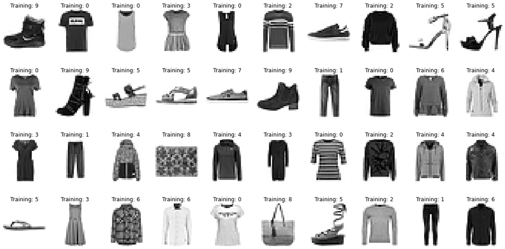

```python
train_dl2, test_dl2 = get_dl_fashionmnist(IMG_SIZE, BATCH_SIZE)

# Draw the first 40 data points - in this case a single data point is an image
plt.figure(1, figsize=(20, 10), dpi=72)
for index in range(40):
    image, label = train_dl2.dataset[index]
    plt.subplot(4, 10, index+1)
    plt.axis('off')
    plt.imshow(image[0].numpy(), cmap=plt.cm.gray_r, interpolation='nearest')
    plt.title(f'Training: {label}')
```

```python
D_HIDDEN= 64

class Discriminator(nn.Module):
    def __init__(self):
        super(Discriminator, self).__init__()
        self.net = nn.Sequential(

            nn.Conv2d(IMG_CHANNEL, D_HIDDEN, 4, 2, 1, bias=False),
            nn.LeakyReLU(0.2, inplace=True),

            nn.Conv2d(D_HIDDEN, D_HIDDEN*2, 4, 2, 1, bias=False),
            nn.BatchNorm2d(D_HIDDEN*2),
            nn.LeakyReLU(0.2, inplace=True),

            nn.Conv2d(D_HIDDEN*2, D_HIDDEN*4, 4, 2, 1, bias=False),
            nn.BatchNorm2d(D_HIDDEN*4),
            nn.LeakyReLU(0.2, inplace=True),

            nn.Conv2d(D_HIDDEN*4, D_HIDDEN*8, 4, 2, 1, bias=False),
            nn.BatchNorm2d(D_HIDDEN*8),
            nn.LeakyReLU(0.2, inplace=True),

            nn.Conv2d(D_HIDDEN*8, 1, 4, 1, 0, bias=False),
            nn.Sigmoid()
        )
    def forward(self, _input):
        return self.net(_input).view(-1, 1).squeeze(1)

# Check the network layers
print(Discriminator())
```

```
Discriminator(
  (net): Sequential(
    (0): Conv2d(1, 64, kernel_size=(4, 4), stride=(2, 2), padding=(1, 1), bias=False)
    (1): LeakyReLU(negative_slope=0.2, inplace=True)
    (2): Conv2d(64, 128, kernel_size=(4, 4), stride=(2, 2), padding=(1, 1), bias=False)
    (3): BatchNorm2d(128, eps=1e-05, momentum=0.1, affine=True, track_running_stats=True)
    (4): LeakyReLU(negative_slope=0.2, inplace=True)
    (5): Conv2d(128, 256, kernel_size=(4, 4), stride=(2, 2), padding=(1, 1), bias=False)
    (6): BatchNorm2d(256, eps=1e-05, momentum=0.1, affine=True, track_running_stats=True)
    (7): LeakyReLU(negative_slope=0.2, inplace=True)
    (8): Conv2d(256, 512, kernel_size=(4, 4), stride=(2, 2), padding=(1, 1), bias=False)
    (9): BatchNorm2d(512, eps=1e-05, momentum=0.1, affine=True, track_running_stats=True)
    (10): LeakyReLU(negative_slope=0.2, inplace=True)
    (11): Conv2d(512, 1, kernel_size=(4, 4), stride=(1, 1), bias=False)
    (12): Sigmoid()
  )
)
```

```python
G_HIDDEN= 64
Z_DIM= 100

class Generator(nn.Module):
    def __init__(self):
        super(Generator, self).__init__()
        self.net = nn.Sequential(

            nn.ConvTranspose2d(Z_DIM, G_HIDDEN*8, 4, 1, 0, bias=False),
            nn.BatchNorm2d(G_HIDDEN*8),
            nn.ReLU(inplace=True),

            nn.ConvTranspose2d(G_HIDDEN*8, G_HIDDEN*4, 4, 2, 1, bias=False),
            nn.BatchNorm2d(G_HIDDEN*4),
            nn.ReLU(inplace=True),

            nn.ConvTranspose2d(G_HIDDEN*4, G_HIDDEN*2, 4, 2, 1, bias=False),
            nn.BatchNorm2d(G_HIDDEN*2),
            nn.ReLU(inplace=True),

            nn.ConvTranspose2d(G_HIDDEN*2, G_HIDDEN, 4, 2, 1, bias=False),
            nn.BatchNorm2d(G_HIDDEN),
            nn.ReLU(inplace=True),

            nn.ConvTranspose2d(G_HIDDEN, IMG_CHANNEL, 4, 2, 1, bias=False),
            nn.Tanh()
        )
    def forward(self, _input):
        return self.net(_input)

# Check the network layers
print(Generator())
```

```
Generator(
  (net): Sequential(
    (0): ConvTranspose2d(100, 512, kernel_size=(4, 4), stride=(1, 1), bias=False)
    (1): BatchNorm2d(512, eps=1e-05, momentum=0.1, affine=True, track_running_stats=True)
    (2): ReLU(inplace=True)
    (3): ConvTranspose2d(512, 256, kernel_size=(4, 4), stride=(2, 2), padding=(1, 1), bias=False)
    (4): BatchNorm2d(256, eps=1e-05, momentum=0.1, affine=True, track_running_stats=True)
    (5): ReLU(inplace=True)
    (6): ConvTranspose2d(256, 128, kernel_size=(4, 4), stride=(2, 2), padding=(1, 1), bias=False)
    (7): BatchNorm2d(128, eps=1e-05, momentum=0.1, affine=True, track_running_stats=True)
    (8): ReLU(inplace=True)
    (9): ConvTranspose2d(128, 64, kernel_size=(4, 4), stride=(2, 2), padding=(1, 1), bias=False)
    (10): BatchNorm2d(64, eps=1e-05, momentum=0.1, affine=True, track_running_stats=True)
    (11): ReLU(inplace=True)
    (12): ConvTranspose2d(64, 1, kernel_size=(4, 4), stride=(2, 2), padding=(1, 1), bias=False)
    (13): Tanh()
  )
)
```

```python
%%time

X_DIM= 64
BATCH_SIZE= 1000

train_dl, test_dl = get_dl_fashionmnist(X_DIM, BATCH_SIZE)

# Create the Discriminator and place it in gpu
netD = Discriminator().to(device)
netD.apply(init_weights)

# Create the Generator and place it in gpu
netG = Generator().to(device)
netG.apply(init_weights)

# Optimizers
criterion = nn.BCELoss()
optimizerD = optim.Adam(netD.parameters(), lr=ETA, betas=(0.5, 0.999))
optimizerG = optim.Adam(netG.parameters(), lr=ETA, betas=(0.5, 0.999))

info= True
EPOCHS= 50

# Learning the real and fake - reminder this is not a classification problem
REAL_LABEL= 1
FAKE_LABEL= 0

# Same noise sample to generate the sample fake
viz_noise = torch.randn(BATCH_SIZE, Z_DIM, 1, 1, device=device)

for e in range(EPOCHS):
    for i, data in enumerate(train_dl):
        x_real = data[0].to(device)
        real_label = torch.full((x_real.size(0),), REAL_LABEL, dtype=torch.float32, device=device)
        fake_label = torch.full((x_real.size(0),), FAKE_LABEL, dtype=torch.float32, device=device)

        # Update D with real data
        netD.zero_grad()
        y_real = netD(x_real)
        loss_D_real = criterion(y_real, real_label)
        loss_D_real.backward()

        # Update D with fake data
        z_noise = torch.randn(x_real.size(0), Z_DIM, 1, 1, device=device)
        x_fake = netG(z_noise)
        y_fake = netD(x_fake.detach())
        loss_D_fake = criterion(y_fake, fake_label)
        loss_D_fake.backward()
        optimizerD.step()

        # Update G with fake data
        netG.zero_grad()
        y_fake_r = netD(x_fake)
        loss_G = criterion(y_fake_r, real_label)
        loss_G.backward()
        optimizerG.step()

        if info:
            sys.stderr.write("\r{:03d}/{:3d} | LossDr: {:6.2f} | lossDf: {:6.2f} | lossG: {:6.2f}".format(
                e+1, EPOCHS, loss_D_real.mean().item(), loss_D_fake.mean().item(), loss_G.mean().item()))
            sys.stderr.flush()

            if i == 0:
                with torch.no_grad():
                    viz_sample = netG(viz_noise)
                    vutils.save_image(vutils.make_grid(viz_sample[:32], nrow=4),
                                      f'./gan_output/fake_samples_{e}.png', normalize=True)

    if info:
        torch.save(netG.state_dict(), f'./gan_output/netG_{e}.pth')
        torch.save(netD.state_dict(), f'./gan_output/netD_{e}.pth')
```

```
050/ 50 | LossDr:   0.65 | lossDf:   0.07 | lossG:   2.02
```

```
CPU times: total: 12min 30s
Wall time: 10min 48s
```

Now let's check what was learned.

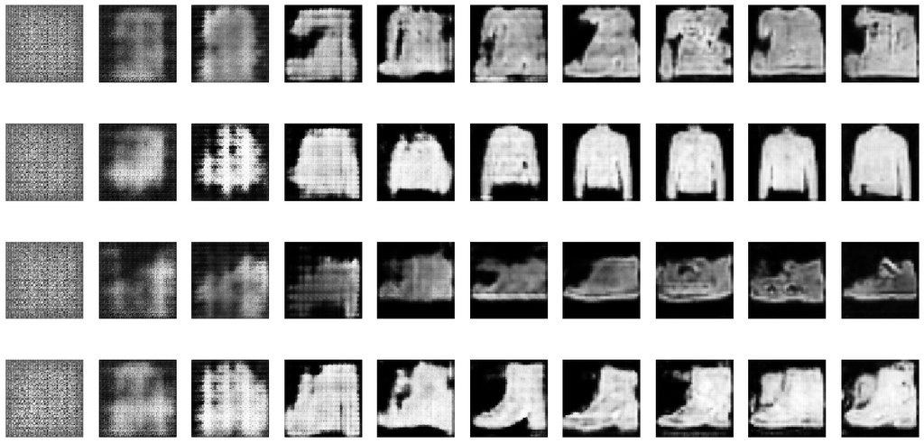

```python
# Draw stored fake epochs
def draw_strip(_row, _col, _offset):
    # epoch
    ix = (0, 1, 2, 5, 10, 15, 20, 25, 30, EPOCHS-1)
    # position excluding the grid
    def img_xy(x, y):
        return 2*(x+1)+64*x, 2*(y+1)+64*y

    x, y = img_xy(_row,_col)
    for i, e in enumerate(ix):
        img = plt.imread(f'./gan_output/fake_samples_{e}.png')
        plt.subplot(4, 10, 10*_offset + i+1)
        plt.axis('off')
        plt.imshow(img[x:x+64,y:y+64], cmap=plt.cm.gray_r, interpolation='nearest')

plt.figure(1, figsize=(20, 10), dpi=72)
draw_strip(0,0,0)
draw_strip(1,0,1)
draw_strip(2,2,2)
draw_strip(3,0,3)
```

And generate some fake fashion MNIST images.

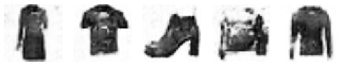

```python
# Load saved weights, generate a fake image
netG2 = Generator()
netG2.load_state_dict(torch.load(f'./gan_output/netG_{EPOCHS-1:d}.pth'))
netG2.to(device)

plt.figure(1, figsize=(10, 5), dpi=72)
for i in range(5):
    plt.subplot(1, 5, i+1)
    with torch.no_grad():
        x_fake = netG2(torch.randn(1, Z_DIM, 1, 1, device=device))
    plt.axis('off')
    plt.imshow(x_fake.to('cpu').numpy().reshape(64,64), cmap=plt.cm.gray_r, interpolation='nearest')
plt.show()
```

## Problems and Improvements

### Mode Collapse

The generator finds a small number of sample that deceive the discriminator, and as a result will not produce any new fake examples. A single observation (a mode) that always deceived the discriminator will map every point in the latent input space to this observation.

### Uninformative Loss

A lack of correlation between the generator loss and image quality will make GAN training difficult to optimize and monitor.

### Hyperparameters

The number of hyperparameters are more than doubled compared to a regular deep NN. to tune. Such as batch normalization, dropout, learning rate, activation layers, convolutional filters, kernel size, striding, batch size, and latent space size have to be set. GANs are highly sensitive to very slight changes in hyperparameters.

### Wasserstein GAN

Wasserstein loss function is a better loss metric that correlates with the generator's convergence and sample quality and improves the stability of the optimization process. The discriminator operates like a critic. Reminder,

$\text{BCE-loss}= −\frac{1}{n} \sum_{i=1}^n \big(y_i \log p_i + (1−y_i)\log (1−p_i)\big)$

Then,

$\text{Wasserstein-loss}= −\frac{1}{n} \sum_{i=1}^n (y_i p_i)$

Discriminator (or WGAN critic) loss is computed when comparing predictions for real sample $p_i=D(x_i)$ to the response $y_i=1$ and predictions for generated sample $p_i=D(G(z_i))$ to the response $y_i=-1$. Therefore, the WGAN critic loss minimization,

$\underset{D}{\min} \big(\mathbf{E}_{x \sim P_X} [D(x)] - \mathbf{E}_{z \sim P_Z} [D(G(z))] \big)$

And WGAN generator loss minimization,

$\underset{G}{\min} \big(\mathbf{E}_{z \sim P_Z} [D(G(z))] \big)$

#### Implementation

- Update the loss function
- Change real and fake outputs to $1$ and $-1$
- Remove the sigmoid activation function of the discriminator

#### WGAN-GP

- Loss function includes a gradient penalty term based on multiple interpolated sample
- Skip clipping the weights of the critic network
- Skip batch normalization layers for the critic network

## References

1. Goodfellow, Ian, et al. "Generative adversarial nets." Advances in neural information processing systems 27 (2014).
2. Foster, David. Generative deep learning: teaching machines to paint, write, compose, and play. O'Reilly Media, 2019.
3. Hany, John, and Greg Walters. Hands-On Generative Adversarial Networks with PyTorch 1. x: Implement next-generation neural networks to build powerful GAN models using Python. Packt Publishing Ltd, 2019.
4. Wang, Zhengwei, Qi She, and Tomas E. Ward. "Generative adversarial networks in computer vision: A survey and taxonomy." ACM Computing Surveys (CSUR) 54.2 (2021): 1-38.
5. Arjovsky, Martin, Soumith Chintala, and Léon Bottou. "Wasserstein generative adversarial networks." International conference on machine learning. PMLR, 2017.
6. Gulrajani, Ishaan, et al. "Improved training of wasserstein gans." Advances in neural information processing systems 30 (2017).
7. PyTorch GitHub. https://github.com/pytorch. Accessed Oct 2023.

## Exercises

**Exercise 1.** Run the generation multiple times and estimate the number of different images the `Generator` could generate.

**Exercise 2.** Switch to MNIST dataset and generate fake digits.

```python
%%html
<style>
    table {margin-left: 0 !important;}
</style>
<!-- Display markdown tables left oriented in this notebook. -->
```